# 白葡萄酒数据探索分析

Chris Tan

2017，6，28

# Univariate Plots Section

1.观察白葡萄酒数据集（以下简称数据集,变量名和函数中专业名称采用英文名称）的观察值的数量、变量名的数量、数据类型、结构和统计概要

```
## [1] 4898   13
```

```
## 'data.frame':    4898 obs. of  13 variables:
##  $ X                   : int  1 2 3 4 5 6 7 8 9 10 ...
##  $ fixed.acidity       : num  7 6.3 8.1 7.2 7.2 8.1 6.2 7 6.3 8.1 ...
##  $ volatile.acidity    : num  0.27 0.3 0.28 0.23 0.23 0.28 0.32 0.27 0.3 0.22 ...
##  $ citric.acid         : num  0.36 0.34 0.4 0.32 0.32 0.4 0.16 0.36 0.34 0.43 ...
##  $ residual.sugar      : num  20.7 1.6 6.9 8.5 8.5 6.9 7 20.7 1.6 1.5 ...
##  $ chlorides           : num  0.045 0.049 0.05 0.058 0.058 0.05 0.045 0.045 0.049 0.044 ...
##  $ free.sulfur.dioxide : num  45 14 30 47 47 30 30 45 14 28 ...
##  $ total.sulfur.dioxide: num  170 132 97 186 186 97 136 170 132 129 ...
##  $ density             : num  1.001 0.994 0.995 0.996 0.996 ...
##  $ pH                  : num  3 3.3 3.26 3.19 3.19 3.26 3.18 3 3.3 3.22 ...
##  $ sulphates           : num  0.45 0.49 0.44 0.4 0.4 0.44 0.47 0.45 0.49 0.45 ...
##  $ alcohol             : num  8.8 9.5 10.1 9.9 9.9 10.1 9.6 8.8 9.5 11 ...
##  $ quality             : int  6 6 6 6 6 6 6 6 6 6 ...
```

```
##        X        fixed.acidity    volatile.acidity  citric.acid
##  Min.   :   1   Min.   : 3.800   Min.   :0.0800   Min.   :0.0000
##  1st Qu.:1225   1st Qu.: 6.300   1st Qu.:0.2100   1st Qu.:0.2700
##  Median :2450   Median : 6.800   Median :0.2600   Median :0.3200
##  Mean   :2450   Mean   : 6.855   Mean   :0.2782   Mean   :0.3342
##  3rd Qu.:3674   3rd Qu.: 7.300   3rd Qu.:0.3200   3rd Qu.:0.3900
##  Max.   :4898   Max.   :14.200   Max.   :1.1000   Max.   :1.6600
##  residual.sugar     chlorides       free.sulfur.dioxide
##  Min.   : 0.600   Min.   :0.00900   Min.   :  2.00
##  1st Qu.: 1.700   1st Qu.:0.03600   1st Qu.: 23.00
##  Median : 5.200   Median :0.04300   Median : 34.00
##  Mean   : 6.391   Mean   :0.04577   Mean   : 35.31
##  3rd Qu.: 9.900   3rd Qu.:0.05000   3rd Qu.: 46.00
##  Max.   :65.800   Max.   :0.34600   Max.   :289.00
##  total.sulfur.dioxide    density             pH          sulphates
##  Min.   :  9.0        Min.   :0.9871   Min.   :2.720   Min.   :0.2200
##  1st Qu.:108.0        1st Qu.:0.9917   1st Qu.:3.090   1st Qu.:0.4100
##  Median :134.0        Median :0.9937   Median :3.180   Median :0.4700
##  Mean   :138.4        Mean   :0.9940   Mean   :3.188   Mean   :0.4898
##  3rd Qu.:167.0        3rd Qu.:0.9961   3rd Qu.:3.280   3rd Qu.:0.5500
##  Max.   :440.0        Max.   :1.0390   Max.   :3.820   Max.   :1.0800
##     alcohol         quality
##  Min.   : 8.00   Min.   :3.000
##  1st Qu.: 9.50   1st Qu.:5.000
##  Median :10.40   Median :6.000
##  Mean   :10.51   Mean   :5.878
##  3rd Qu.:11.40   3rd Qu.:6.000
##  Max.   :14.20   Max.   :9.000
```

- 数据集中只有citric acid的最小值是0；
- 因为residual sugar的3rd Qu.: 9.9; （远小于45），所以估计大多数都是不甜的白葡萄酒；
- 大多数pH值介于3到3.28；
- quality的中位数是6，平均值是5.878；即使quality采用0-10评级，但这里只有3-9；

2.quality的直方图

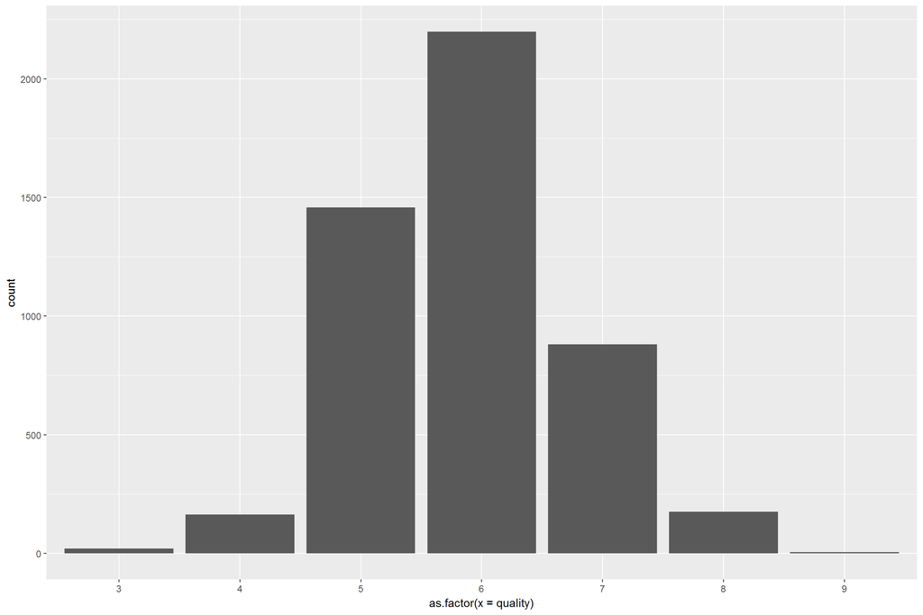

数量排名：等级6是第一，等级5是第二，等级7是第三，等级3跟9极少； 集中在等级5-7；

3.其它11个变量的直方图

3.1 fixed acidity的统计概要和直方图

```
##    Min. 1st Qu.  Median    Mean 3rd Qu.    Max.
##   3.800   6.300   6.800   6.855   7.300  14.200
```

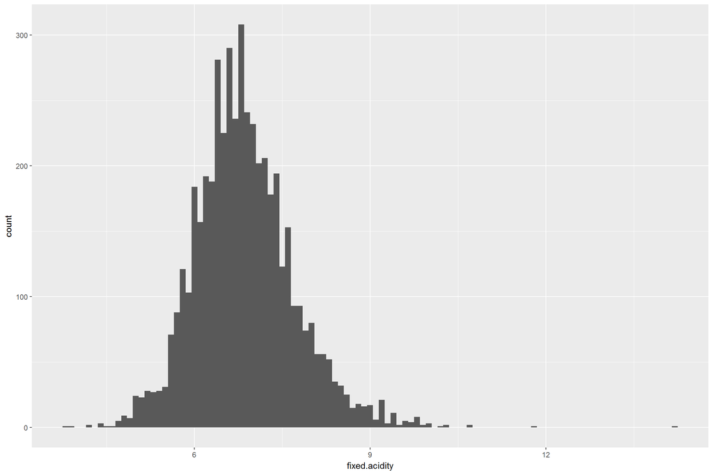

fixed acidity趋向正态分布，酒中fixed acidity成分大多数介于6.3到7.3，中位数是6.8，均值是6.855，有些异常值；

3.2 volatile acidity的统计概要和直方图

```
##    Min. 1st Qu.  Median    Mean 3rd Qu.    Max.
##  0.0800  0.2100  0.2600  0.2782  0.3200  1.1000
```

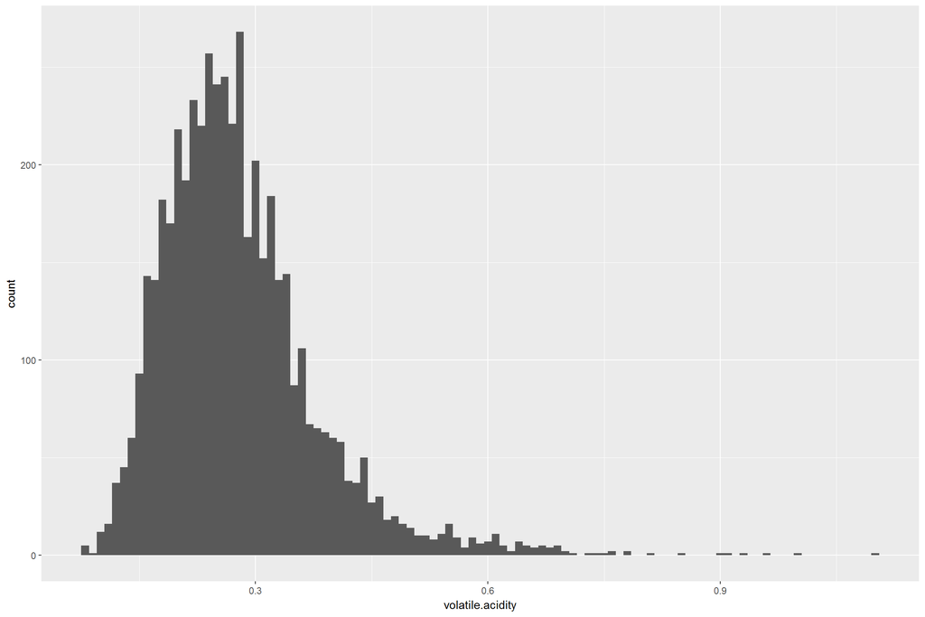

volatile acidity趋向正态分布，有些右偏，酒中volatile acidity成分大多数介于0.21到0.32，中位数是0.26，均值是0.2782，有些异常值；

3.3 citric acid的统计概要和直方图

```
##    Min. 1st Qu.  Median    Mean 3rd Qu.    Max.
##  0.0000  0.2700  0.3200  0.3342  0.3900  1.6600
```

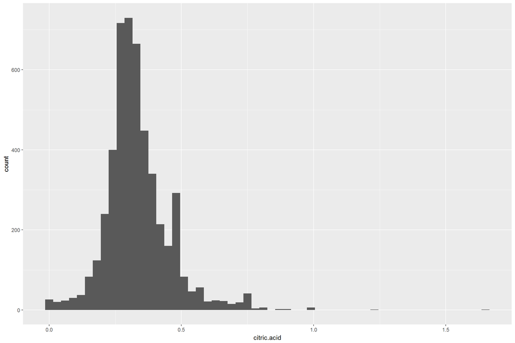

3.4 residual sugar的统计概要和直方图

```
##    Min. 1st Qu.  Median    Mean 3rd Qu.    Max.
##   0.600   1.700   5.200   6.391   9.900  65.800
```

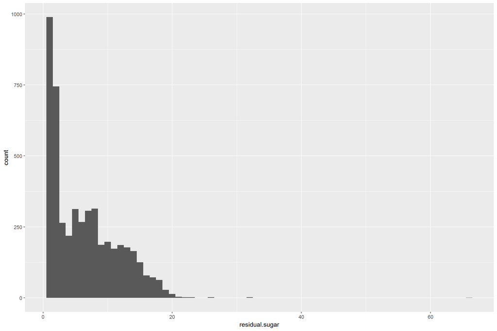

residual sugar趋向右偏分布，酒中residual sugar成分大多数少于6，中位数是5.2，均值是6.391，有些异常值非常高；

调整residual.sugar的直方图

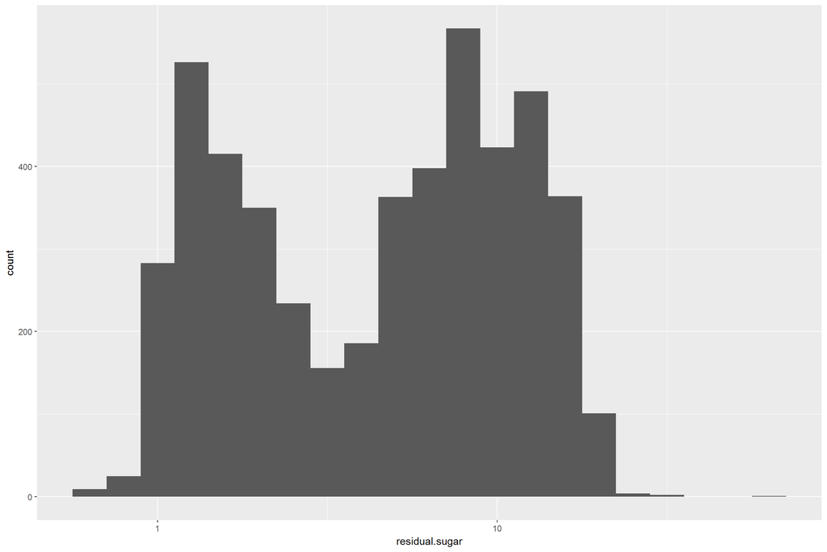

现在residual sugar的图趋向双峰正态分布；

3.5 chlorides的统计概要和直方图

```
##    Min. 1st Qu.  Median    Mean 3rd Qu.    Max.
## 0.00900 0.03600 0.04300 0.04577 0.05000 0.34600
```

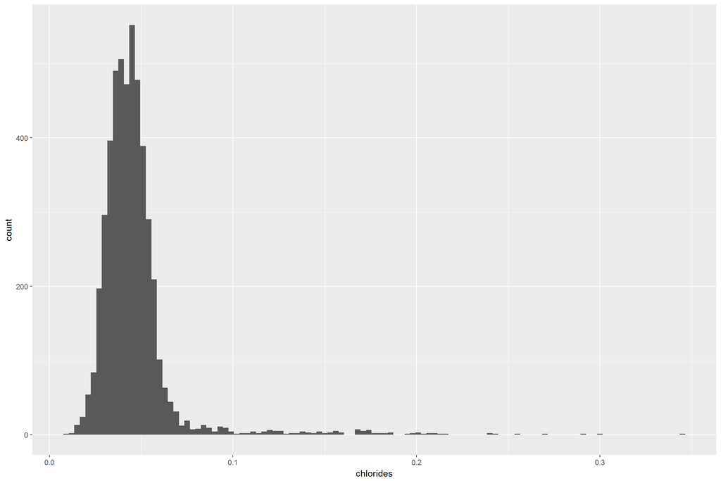

chlorides趋向正态分布，酒中chlorides成分大多数介于0.036到0.05，中位数是0.043，均值是0.04577，有些异常值大于0.1；

3.6 free sulfur dioxide的统计概要和直方图

```
##    Min. 1st Qu.  Median    Mean 3rd Qu.    Max.
##    2.00   23.00   34.00   35.31   46.00  289.00
```

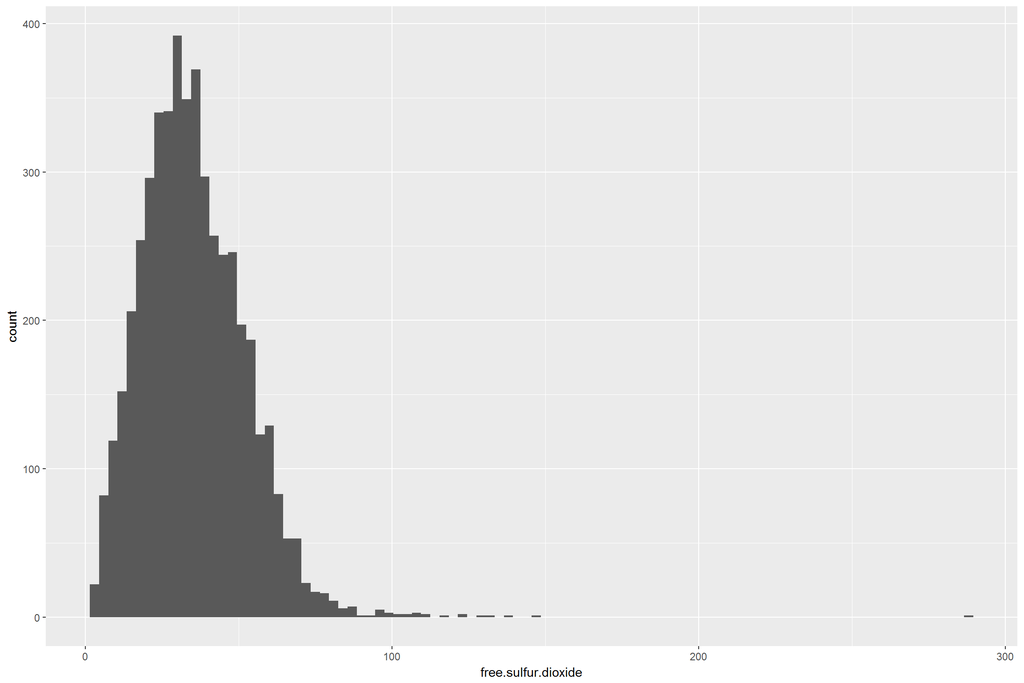

free sulfur dioxide趋向正态分布，酒中free sulfur dioxide成分大多数介于23到46，中位数是34，均值是35.31，有些异常值大于80；

3.7 total sulfur dioxide的统计概要和直方图

```
##    Min. 1st Qu.  Median    Mean 3rd Qu.    Max.
##     9.0   108.0   134.0   138.4   167.0   440.0
```

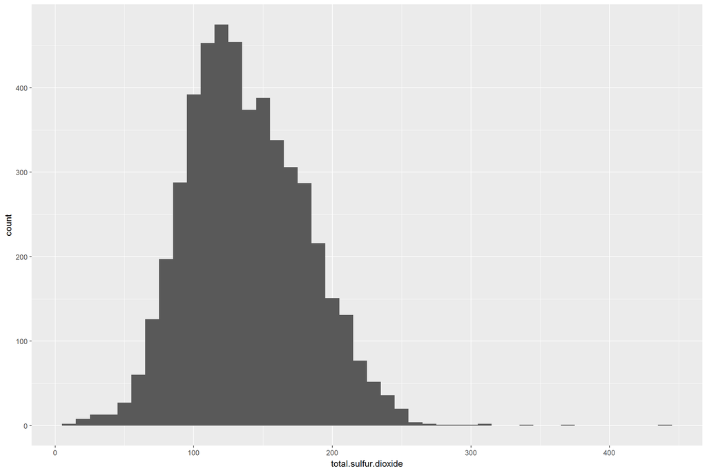

total sulfur dioxide趋向正态分布，酒中total sulfur dioxide成分大多数介于108到167，中位数是134，均值是138.4，有些异常值；

3.8 density的统计概要和直方图

```
##    Min. 1st Qu.  Median    Mean 3rd Qu.    Max.
##  0.9871  0.9917  0.9937  0.9940  0.9961  1.0390
```

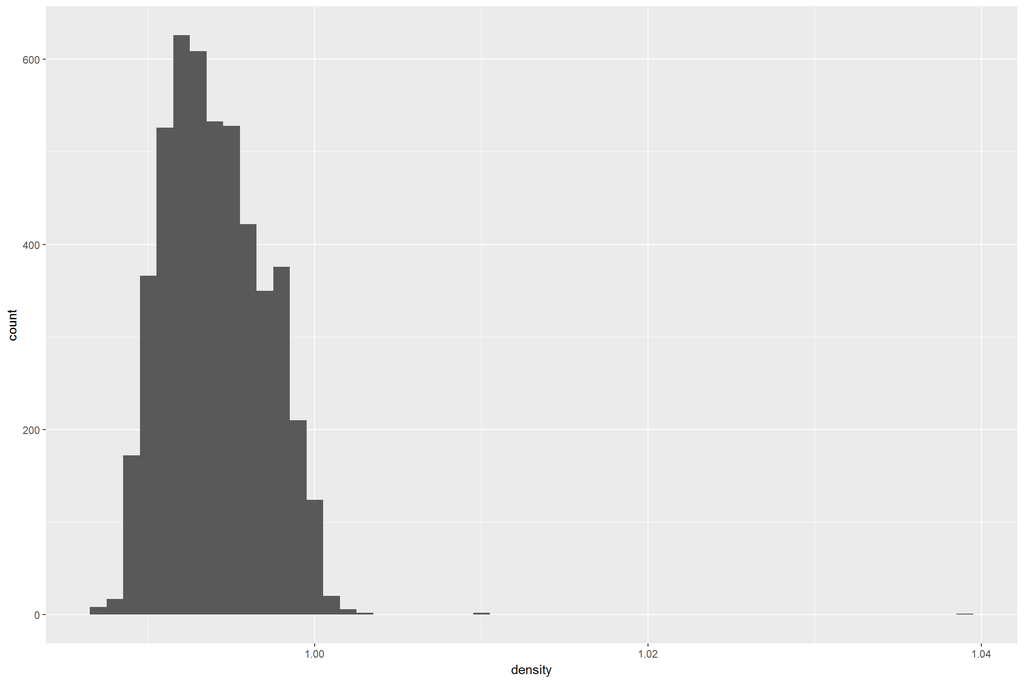

density趋向正态分布，酒中density成分大多数介于0.9871到1，中位数是0.9937，均值是0.994，有些异常值；

3.9 pH的统计概要和直方图

```
##    Min. 1st Qu.  Median    Mean 3rd Qu.    Max.
##   2.720   3.090   3.180   3.188   3.280   3.820
```

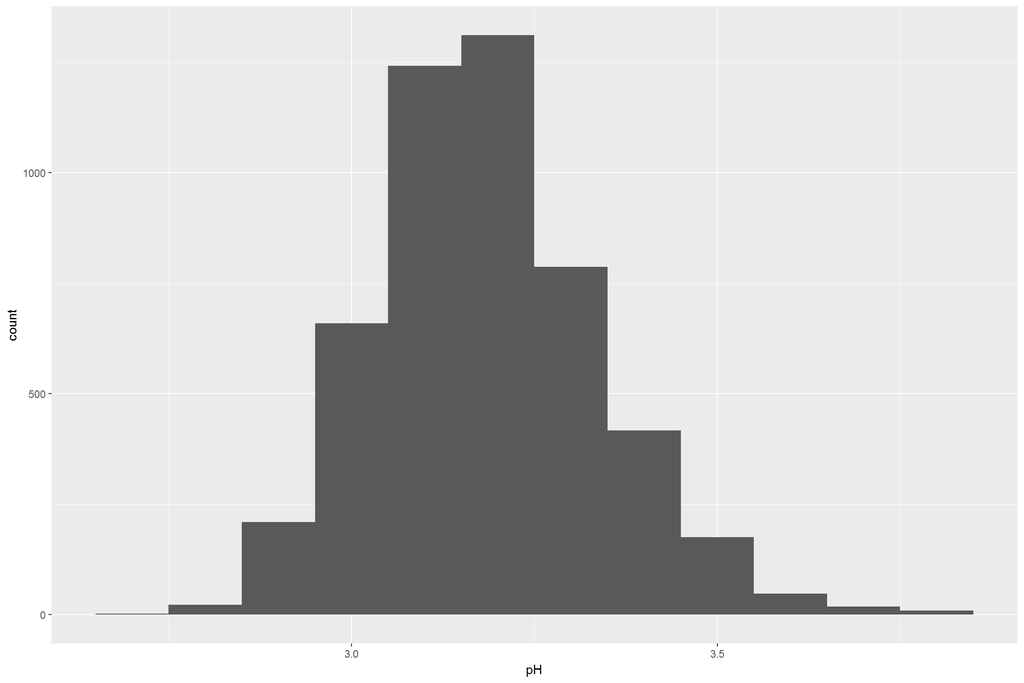

pH趋向正态分布，酒中pH成分大多数介于3.09到3.28，中位数是3.18，均值是3.188，有些异常值；

3.10 sulphates的统计概要和直方图

```
##    Min. 1st Qu.  Median    Mean 3rd Qu.    Max.
##  0.2200  0.4100  0.4700  0.4898  0.5500  1.0800
```

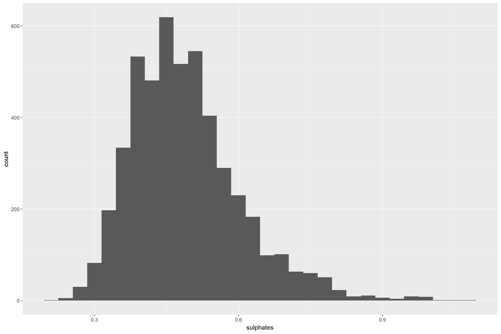

sulphates趋向正态分布，有些右偏，酒中sulphates成分大多数介于0.41到0.55，中位数是0.47，均值是0.4898，有些异常值；

3.11 alcohol的统计概要和直方图

```
##    Min. 1st Qu.  Median    Mean 3rd Qu.    Max.
##    8.00    9.50   10.40   10.51   11.40   14.20
```

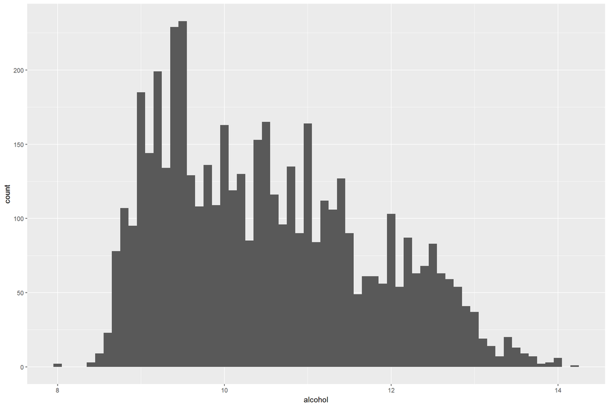

4.去掉底部和顶端1%，减少异常值的影响

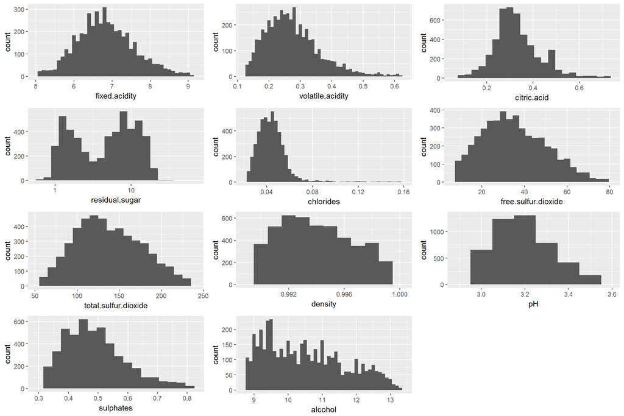

现在图的可读性提高，也为分析减少误差；

# Univariate Analysis

### What is the structure of your dataset?

数据集包含4898个白葡萄就观测值和11个量化特徵(fixed.acidity, volatile .acidity, citric.acid, residual.sugar, chlorides, free.sulfur.dioxide, total.sulfur.dioxide, density, pH, sulphates, and alcohol)都是数值型，没有因子。 因为变量quality是将葡萄酒的评分从低到高分成0-10，所以作图前，先将quality转换为因子；

其它：

- 数据集中只有citric.acid的最小值是0；
- 因为residual.sugar的3rd Qu.: 9.9 （远小于45），所以估计大多数都是不甜的白葡萄酒；
- 大多数pH值介于3到3.28；
- quality的中位数是6，平均值是5.878；即使quality有0-10评级，但这里只有3-9；

### What is/are the main feature(s) of interest in your dataset?

因为quality是因变量，其它11个是独立变量，所以quality是我们研究对象；

### What other features in the dataset do you think will help support your investigation into your feature(s) of interest?

11个独立变量都可能有助于研究quality；我想可以基于独立变量与因变量的相关性，进行选择；

### Did you create any new variables from existing variables in the dataset?

还没创建新的变量；

### Of the features you investigated, were there any unusual distributions? Did you perform any operations on the data to tidy, adjust, or change the form of the data? If so, why did you do this?

第一个调整是先将quality数据类型转换为因子，然后用作作图，利于分析；

第二个是residual sugar的直方图长尾显著，我调整x轴为log10，使它的图趋向双峰正态分布；

第三个是调整直方图的组距和去掉异常值，使直方图主体的分布更清晰直观。

# Bivariate Plots Section

```
## [1] "每个独立变量与因变量quality的相关系数"
```

```
##        fixed.acidity     volatile.acidity          citric.acid
##               -0.114               -0.195               -0.009
##       residual.sugar            chlorides  free.sulfur.dioxide
##               -0.098               -0.210                0.008
## total.sulfur.dioxide              density                   pH
##               -0.175               -0.307                0.099
##            sulphates              alcohol
##                0.054                0.436
```

每个独立变量独自与因变量的相关系不强，后面需要将它们组合一起，可能利于预测quality。

相关性由强到弱排名前五是：

- Quality和alcohol: 0.436
- Quality和density: -0.307
- Quality和chlorides: -0.210
- Quality和volatile.acidity：-0.195
- Quality和total.sulfur.dioxide：-0.175

1.各级别quality下的alcohol分布

```
## [1] "alcohol by quality的统计概要"
```

```
## wines$quality: 3
##    Min. 1st Qu.  Median    Mean 3rd Qu.    Max.
##    8.00    9.55   10.45   10.34   11.00   12.60
## --------------------------------------------------------
## wines$quality: 4
##    Min. 1st Qu.  Median    Mean 3rd Qu.    Max.
##    8.40    9.40   10.10   10.15   10.75   13.50
## --------------------------------------------------------
## wines$quality: 5
##    Min. 1st Qu.  Median    Mean 3rd Qu.    Max.
##   8.000   9.200   9.500   9.809  10.300  13.600
## --------------------------------------------------------
## wines$quality: 6
##    Min. 1st Qu.  Median    Mean 3rd Qu.    Max.
##    8.50    9.60   10.50   10.58   11.40   14.00
## --------------------------------------------------------
## wines$quality: 7
##    Min. 1st Qu.  Median    Mean 3rd Qu.    Max.
##    8.60   10.60   11.40   11.37   12.30   14.20
## --------------------------------------------------------
## wines$quality: 8
##    Min. 1st Qu.  Median    Mean 3rd Qu.    Max.
##    8.50   11.00   12.00   11.64   12.60   14.00
## --------------------------------------------------------
## wines$quality: 9
##    Min. 1st Qu.  Median    Mean 3rd Qu.    Max.
##   10.40   12.40   12.50   12.18   12.70   12.90
```

```
## [1] "单因素方差分析"
```

```
##               Df Sum Sq Mean Sq F value Pr(>F)
## alcohol        1  728.7   728.7    1146 <2e-16 ***
## Residuals   4896 3112.3     0.6
## ---
## Signif. codes:  0 '***' 0.001 '**' 0.01 '*' 0.05 '.' 0.1 ' ' 1
```

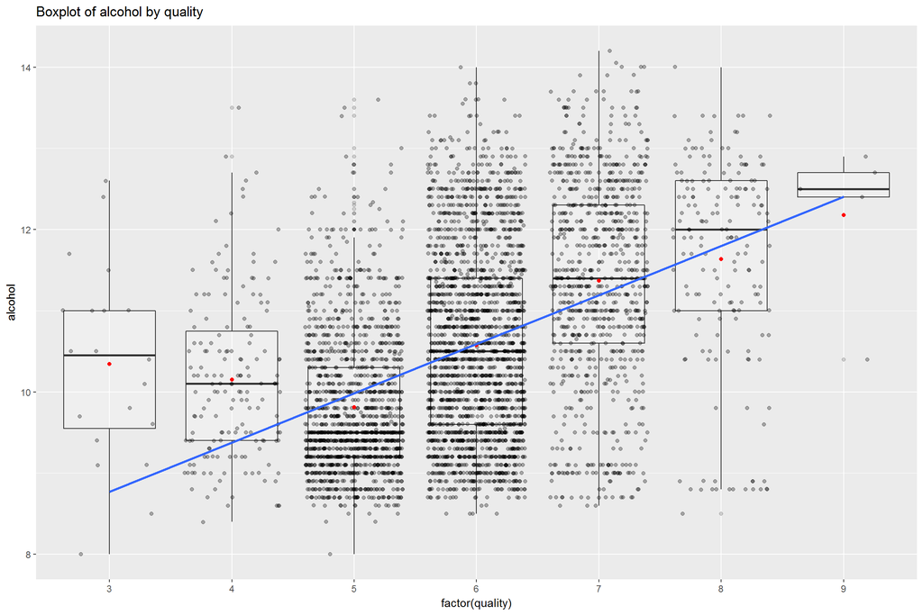

单因素方差分析显示alcohol对quality影响显著；

当quality级别变大，alcohol的值呈现增加的趋势；

2.各级别quality下的density的分布

```
## [1] "density by quality的统计概要"
```

```
## wines$quality: 3
##    Min. 1st Qu.  Median    Mean 3rd Qu.    Max.
##  0.9911  0.9925  0.9944  0.9949  0.9969  1.0000
## --------------------------------------------------------
## wines$quality: 4
##    Min. 1st Qu.  Median    Mean 3rd Qu.    Max.
##  0.9892  0.9926  0.9941  0.9943  0.9958  1.0000
## --------------------------------------------------------
## wines$quality: 5
##    Min. 1st Qu.  Median    Mean 3rd Qu.    Max.
##  0.9872  0.9933  0.9953  0.9953  0.9972  1.0020
## --------------------------------------------------------
## wines$quality: 6
##    Min. 1st Qu.  Median    Mean 3rd Qu.    Max.
##  0.9876  0.9917  0.9937  0.9940  0.9959  1.0390
## --------------------------------------------------------
## wines$quality: 7
##    Min. 1st Qu.  Median    Mean 3rd Qu.    Max.
##  0.9871  0.9906  0.9918  0.9925  0.9937  1.0000
## --------------------------------------------------------
## wines$quality: 8
##    Min. 1st Qu.  Median    Mean 3rd Qu.    Max.
##  0.9871  0.9903  0.9916  0.9922  0.9935  1.0010
## --------------------------------------------------------
## wines$quality: 9
##    Min. 1st Qu.  Median    Mean 3rd Qu.    Max.
##  0.9896  0.9898  0.9903  0.9915  0.9906  0.9970
```

```
## [1] "单因素方差分析"
```

```
##               Df Sum Sq Mean Sq F value Pr(>F)
## density        1    362   362.3   509.9 <2e-16 ***
## Residuals   4896   3479     0.7
## ---
## Signif. codes:  0 '***' 0.001 '**' 0.01 '*' 0.05 '.' 0.1 ' ' 1
```

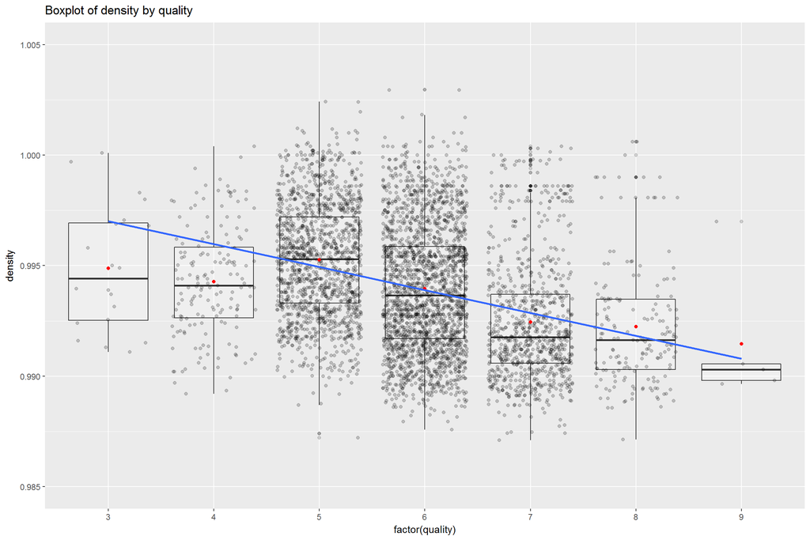

单因素方差分析显示density对quality影响显著；

当quality级别变大，density的值呈现减少的趋势；

3.各级别quality下的chlorides的分布

```
## [1] "chlorides by quality的统计概要"
```

```
## wines$quality: 3
##    Min. 1st Qu.  Median    Mean 3rd Qu.    Max.
## 0.02200 0.03625 0.04100 0.05430 0.05400 0.24400
## --------------------------------------------------------
## wines$quality: 4
##    Min. 1st Qu.  Median    Mean 3rd Qu.    Max.
##  0.0130  0.0380  0.0460  0.0501  0.0540  0.2900
## --------------------------------------------------------
## wines$quality: 5
##    Min. 1st Qu.  Median    Mean 3rd Qu.    Max.
## 0.00900 0.04000 0.04700 0.05155 0.05300 0.34600
## --------------------------------------------------------
## wines$quality: 6
##    Min. 1st Qu.  Median    Mean 3rd Qu.    Max.
## 0.01500 0.03600 0.04300 0.04522 0.04900 0.25500
## --------------------------------------------------------
## wines$quality: 7
##    Min. 1st Qu.  Median    Mean 3rd Qu.    Max.
## 0.01200 0.03100 0.03700 0.03819 0.04400 0.13500
## --------------------------------------------------------
## wines$quality: 8
##    Min. 1st Qu.  Median    Mean 3rd Qu.    Max.
## 0.01400 0.03000 0.03600 0.03831 0.04400 0.12100
## --------------------------------------------------------
## wines$quality: 9
##    Min. 1st Qu.  Median    Mean 3rd Qu.    Max.
##  0.0180  0.0210  0.0310  0.0274  0.0320  0.0350
```

```
## [1] "单因素方差分析"
```

```
##               Df Sum Sq Mean Sq F value Pr(>F)
## chlorides      1    169  169.28   225.7 <2e-16 ***
## Residuals   4896   3672    0.75
## ---
## Signif. codes:  0 '***' 0.001 '**' 0.01 '*' 0.05 '.' 0.1 ' ' 1
```

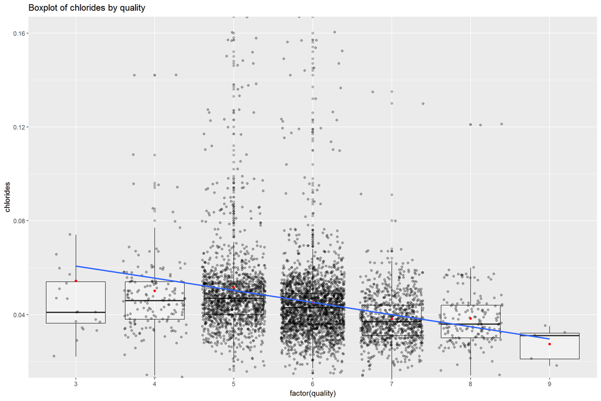

单因素方差分析显示chlorides对quality影响显著；

当quality级别变大，chlorides的值呈现减少的趋势；

4.各级别quality下的volatile acidity的分布

```
## [1] "volatile.acidity by quality的统计概要"
```

```
## wines$quality: 3
##    Min. 1st Qu.  Median    Mean 3rd Qu.    Max.
##  0.1700  0.2375  0.2600  0.3332  0.4125  0.6400
## --------------------------------------------------------
## wines$quality: 4
##    Min. 1st Qu.  Median    Mean 3rd Qu.    Max.
##  0.1100  0.2700  0.3200  0.3812  0.4600  1.1000
## --------------------------------------------------------
## wines$quality: 5
##    Min. 1st Qu.  Median    Mean 3rd Qu.    Max.
##   0.100   0.240   0.280   0.302   0.340   0.905
## --------------------------------------------------------
## wines$quality: 6
##    Min. 1st Qu.  Median    Mean 3rd Qu.    Max.
##  0.0800  0.2000  0.2500  0.2606  0.3000  0.9650
## --------------------------------------------------------
## wines$quality: 7
##    Min. 1st Qu.  Median    Mean 3rd Qu.    Max.
##  0.0800  0.1900  0.2500  0.2628  0.3200  0.7600
## --------------------------------------------------------
## wines$quality: 8
##    Min. 1st Qu.  Median    Mean 3rd Qu.    Max.
##  0.1200  0.2000  0.2600  0.2774  0.3300  0.6600
## --------------------------------------------------------
## wines$quality: 9
##    Min. 1st Qu.  Median    Mean 3rd Qu.    Max.
##   0.240   0.260   0.270   0.298   0.360   0.360
```

```
## [1] "单因素方差分析"
```

```
##                    Df Sum Sq Mean Sq F value Pr(>F)
## volatile.acidity    1    146  145.64     193 <2e-16 ***
## Residuals        4896   3695    0.75
## ---
## Signif. codes:  0 '***' 0.001 '**' 0.01 '*' 0.05 '.' 0.1 ' ' 1
```

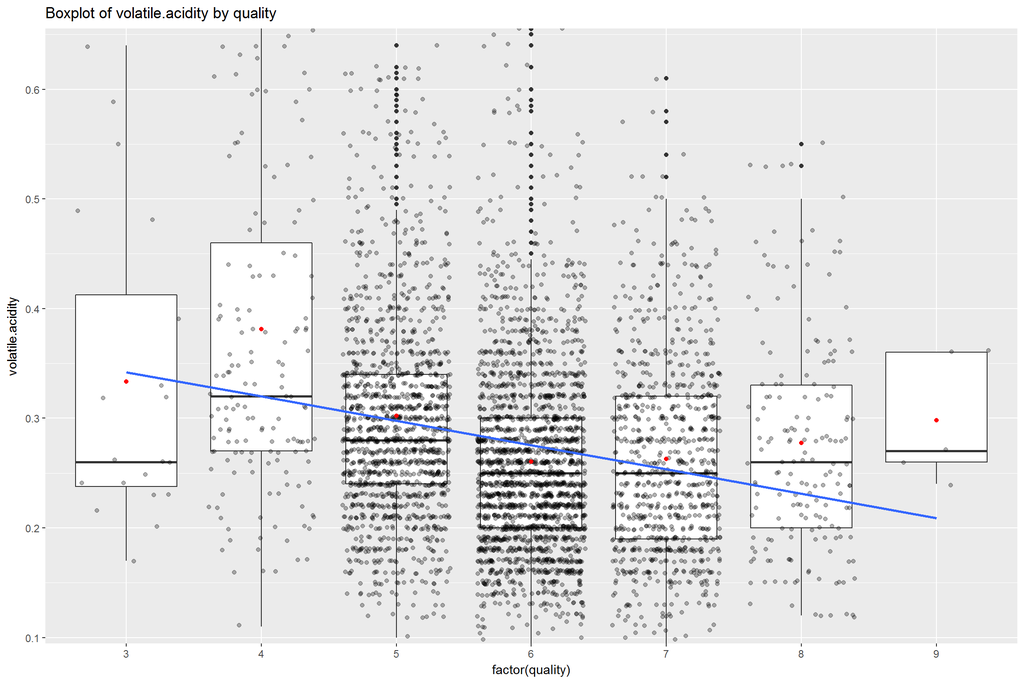

单因素方差分析显示volatile acidity对quality影响显著；

当quality级别变大，volatile acidity的值呈现减少的趋势；

5.各级别quality下的total sulfur dioxide的分布

```
## [1] "total.sulfur.dioxide by quality的统计概要"
```

```
## wines$quality: 3
##    Min. 1st Qu.  Median    Mean 3rd Qu.    Max.
##    19.0   105.8   159.5   170.6   210.0   440.0
## --------------------------------------------------------
## wines$quality: 4
##    Min. 1st Qu.  Median    Mean 3rd Qu.    Max.
##    10.0    85.0   117.0   125.3   171.5   272.0
## --------------------------------------------------------
## wines$quality: 5
##    Min. 1st Qu.  Median    Mean 3rd Qu.    Max.
##     9.0   121.0   151.0   150.9   182.0   344.0
## --------------------------------------------------------
## wines$quality: 6
##    Min. 1st Qu.  Median    Mean 3rd Qu.    Max.
##    18.0   107.2   132.0   137.0   164.0   294.0
## --------------------------------------------------------
## wines$quality: 7
##    Min. 1st Qu.  Median    Mean 3rd Qu.    Max.
##    34.0   101.0   122.0   125.1   144.2   229.0
## --------------------------------------------------------
## wines$quality: 8
##    Min. 1st Qu.  Median    Mean 3rd Qu.    Max.
##    59.0   102.5   122.0   126.2   150.0   212.5
## --------------------------------------------------------
## wines$quality: 9
##    Min. 1st Qu.  Median    Mean 3rd Qu.    Max.
##      85     113     119     116     124     139
```

```
## [1] "单因素方差分析"
```

```
##                        Df Sum Sq Mean Sq F value Pr(>F)
## total.sulfur.dioxide    1    117  117.28   154.2 <2e-16 ***
## Residuals            4896   3724    0.76
## ---
## Signif. codes:  0 '***' 0.001 '**' 0.01 '*' 0.05 '.' 0.1 ' ' 1
```

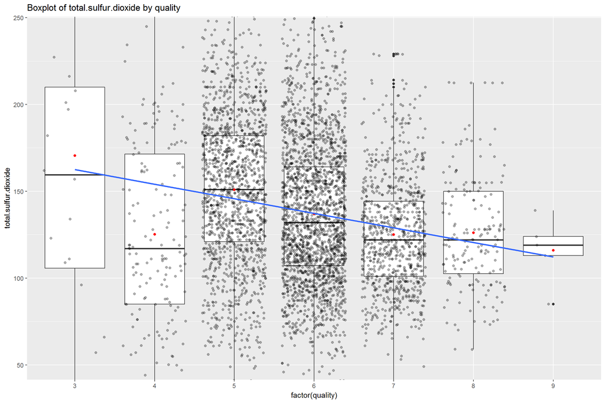

单因素方差分析显示total sulfur dioxide对quality影响显著；

当quality级别低，total sulfur dioxide变高；当quality级别高，total sulfur dioxide变低；

# Bivariate Analysis

### Talk about some of the relationships you observed in this part of the investigation. How did the feature(s) of interest vary with other features in the dataset?

当quality级别变高，变量alcohol，density，chlorides，volatile acidity，total sulfur dioxide趋向一个方向改变，有增大或减少的趋势；

### Did you observe any interesting relationships between the other features (not the main feature(s) of interest)?

- alcohol和density:-0.780
- density和total.sulfur.dioxide:0.530
- chlorides和alcohol:-0.360
- volatile.acidity和total.sulfur.dioxide :0.089
- chlorides和total.sulfur.dioxide：0.198

因为alcohol和density这一对相关性最大（负相关），所以可以观测他们对quality影响；

同时，volatile acidity与其它独立变量相关性微弱，所以剩下chlorides和total sulfur dioxide这组合；

### What was the strongest relationship you found?

alcohol，density，chlorides，volatile acidity，total sulfur dioxide5个独立变量中，alcohol和density这一对相关性最大-0.780（负相关）；

# Multivariate Plots Section

1.alcohol和density对quality的影响分布

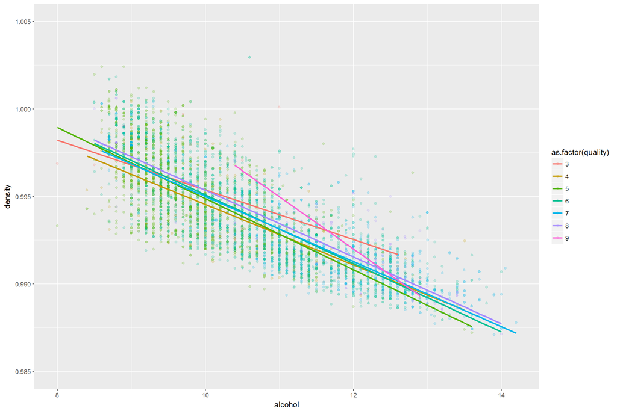

quality级别高（7~9），聚集在高acohol低density区域；

2.chlorides和total sulfur dioxide对quality的影响分布

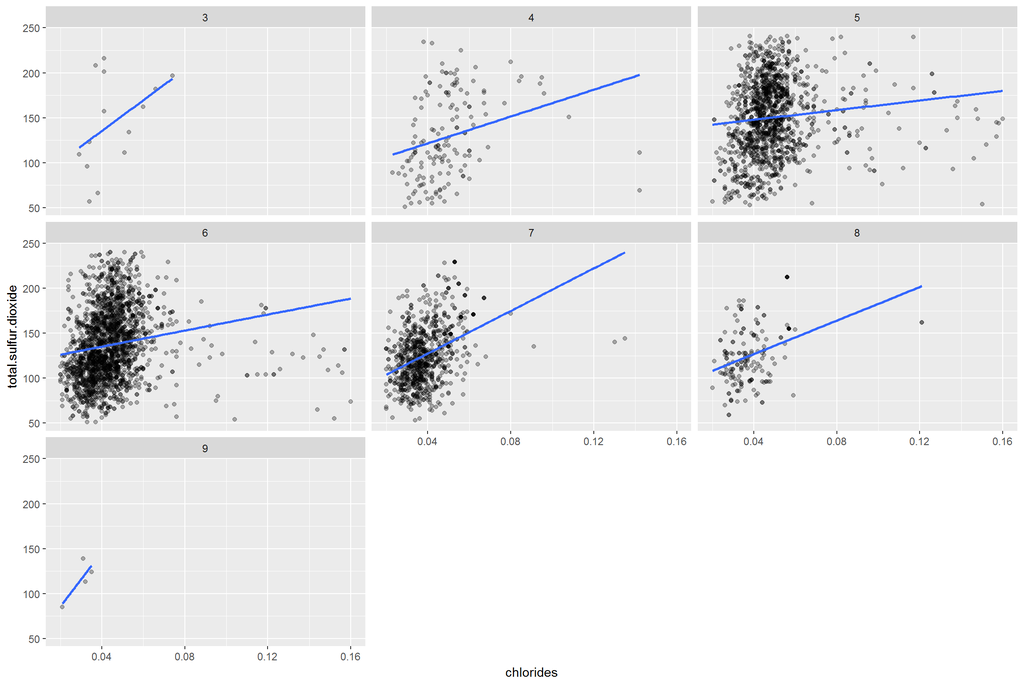

chlorides和total sulfur dioxide分布广，聚集在低浓度的区域；

1.建线性模型

```
##
## Calls:
## m1: lm(formula = I(quality ~ alcohol), data = wines)
## m2: lm(formula = quality ~ alcohol + density, data = wines)
## m3: lm(formula = quality ~ alcohol + density + chlorides, data = wines)
## m4: lm(formula = quality ~ alcohol + density + chlorides + volatile.acidity,
##     data = wines)
## m5: lm(formula = quality ~ alcohol + density + chlorides + volatile.acidity +
##     total.sulfur.dioxide, data = wines)
##
## ===================================================================================
##                            m1          m2          m3          m4          m5
## -----------------------------------------------------------------------------------
##   (Intercept)            2.582***  -22.492***  -21.150***  -35.573***  -30.759***
##                         (0.098)     (6.165)     (6.162)     (6.010)     (6.295)
##   alcohol                0.313***    0.360***    0.343***    0.389***    0.391***
##                         (0.009)     (0.015)     (0.015)     (0.015)     (0.015)
##   density                           24.728***   23.671***   38.217***   33.251***
##                                     (6.079)     (6.074)     (5.926)     (6.234)
##   chlorides                                     -2.382***   -1.300*     -1.370*
##                                                 (0.558)     (0.542)     (0.543)
##   volatile.acidity                                          -2.043***   -2.070***
##                                                             (0.111)     (0.111)
##   total.sulfur.dioxide                                                   0.001*
##                                                                         (0.000)
## -----------------------------------------------------------------------------------
##   R-squared                  0.2        0.2         0.2         0.2         0.2
##   adj. R-squared             0.2        0.2         0.2         0.2         0.2
##   sigma                      0.8        0.8         0.8         0.8         0.8
##   F                       1146.4      583.3       396.3       403.0       324.0
##   p                          0.0        0.0         0.0         0.0         0.0
##   Log-likelihood         -5839.4    -5831.1     -5822.0     -5657.3     -5654.0
##   Deviance                3112.3     3101.8      3090.2      2889.2      2885.4
##   AIC                    11684.8    11670.3     11654.0     11326.6     11322.1
##   BIC                    11704.3    11696.2     11686.5     11365.6     11367.5
##   N                       4898       4898        4898        4898        4898
## ===================================================================================
```

没有一个线性模型是对白葡萄酒的quality有非常好的预测。包含5个变量的线性模型的R2值是0.2，相关性不强，还有残差；也许需要将这些变量进行非线性转换。

alcohol，density和volatile acidity显著性是3颗星，对模型有重要作用；

# Multivariate Analysis

### Talk about some of the relationships you observed in this part of the investigation. Were there features that strengthened each other in terms of looking at your feature(s) of interest?

简单明了可视化一些关系：我加强对alcohol，density，chlorides，volatile acidity，total sulfur dioxide之间关系的了解。

### Were there any interesting or surprising interactions between features?

我发现alcohol与quality是正相关，在箱线图，级别高的quality（6~9）中alcohol是稳定增加；

另外，我发现alcohol与density的关系也有趣，具体如Multivariate Plots Section中的图

### OPTIONAL: Did you create any models with your dataset? Discuss the strengths and limitations of your model.

建立线性模型，基于其它解释变量预测白葡萄quality，主要选取与quality相关性较强的变量；

统计结果显示线性模型可能不是最好的方法；R2值很低，残差较大；

为了完善模型，我可能需要加入新的变量，或者转换非线性模型进行预测；

# Final Plots and Summary

### Plot One

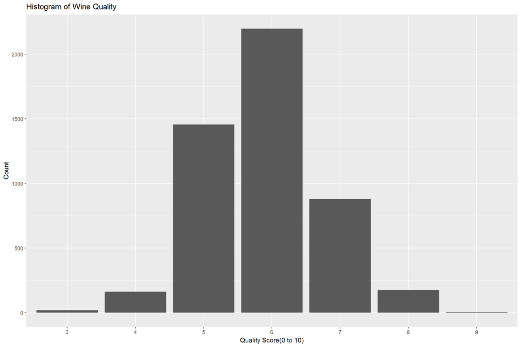

### Description One

数量排名：等级6是第一，等级5是第二，等级7是第三，等级3跟9极少； 集中在等级5-7；

### Plot Two

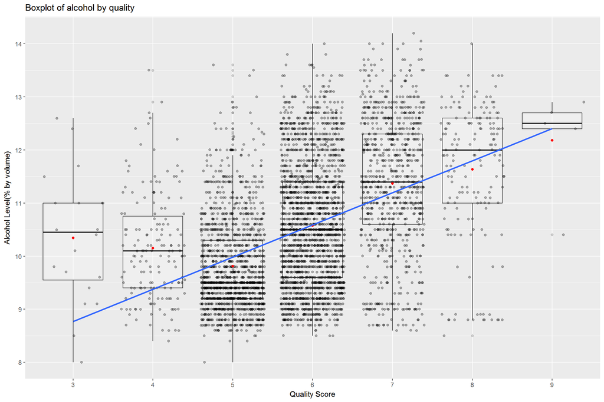

### Description Two

quality和alcohol的相关性是0.436，是quality与其它变量相关性最强的一个；

这个图将这种关系可视化：

- 其中散点图显示从左到右有向上的趋势，alcohol水平增加，quality水平也增加；
- 箱线图显示当quality从3-5，alcohol的中位数是逐渐减少；当quality从5-9，alcohol的中位数是逐渐增加；也许有个很小的alcohol临界值影响quality增加；

### Plot Three

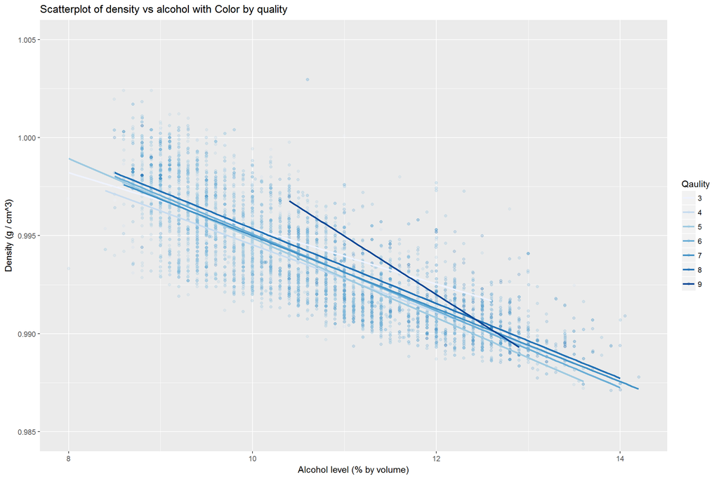

### Description Three

散点图从左往右是下降的趋势：

- 当alcohol水平增加，density减少，这表明alcohol是葡萄酒中一个密度低的成分；
- 当alcohol水平增加，density减少，quality增加，就是说，quality级别高（6~9），聚集在高acohol低density区域；

# Reflection

这项目教会我怎样用R探索数据，主要是学会运用强大的工具包去探索数据：

- 如函数dim,str和quantitle等；
- 作图：散点图，直方图，箱线图和直线（调整多个参数设置透明度，抖动和分面等）；
- 运用线性模型进行基本分析，使用R markdown作报告；

困难或者挑战：

- 为数据选择合适统计方法，
- 花很多时间debug

分析过程的反思：

- 单个变量根本不能预示白葡萄酒的quality，采用多解释变量组合，建立线性模型进行预测比较合适；
- 我的线性模型是低R2高残差，也许需要更换解释变量，或者使用非线性模型；
- 这次分析基于变量的相关性，但仍然需要研究没有相关性的变量；

未来工作建议：

- 采集更多变量信息；
- 学习ordinal logistic regression；
- 学习机器学习算法，构建模型进行预测；